# Entrega N° 1 - Grupo 01

# Práctica 1

## Ejercicio 1 (Aylén)

Análisis del artículo: “Characterizing mutagenic effects of recombination through a sequencelevel genetic map” (Halldorsson et al, 2019). 1. Leer el resumen de investigación (adjunto en este documento). Identificar el tema y el objetivo del trabajo. 2. Al final de este documento se agrega una selección de figuras tomadas del artículo. Identificar una figura donde se observe cada uno de los hallazgos resaltados en la sección Results del resumen. 3. Acerca de la figura 2D: describir la distribución de la distancia desde una mutación de novo (DNM) hasta un crossover (CO,) y comparar entre CO maternos y paternos. 4. Acerca de las figuras 2A y 2E: a. ¿Qué sucede con la tasa de (DNM) a medida que aumenta la distancia desde un crossover (CO)? b. ¿Se diferencia la tasa de DNM según se encuentren alrededor de un CO materno o paterno? c. ¿Cómo se compara la tasa de DNM en cercanías de CO frente a la tasa global de DNM en el genoma? d. ¿Qué diferencia hay entre las figuras 2A y 2E? e. ¿Qué representan los puntos? ¿Qué representan las líneas? ¿Hay mayor variabilidad en la tasa de DNM a mayor distancia del CO? Observar y comentar la escala elegida. 5. Acerca de la figura 2C: ¿cuáles son las tres variables cualitativas representadas? 6. Acerca de la figura 2B: a. Mencionar un tipo de mutación que ocurre con frecuencia similar, ya sea en todo el genoma (materno o paterno) o cerca de un CO (materno o paterno). b. Mencionar un tipo de mutación que ocurre con mayor frecuencia en cercanía a un CO materno.

# Práctica 2

## Ejercicio 5 (Gonzalo)

La concentración sérica de 25-hidroxivitamina D (25-OHD) es utilizada como indicador del estado nutricional de Vitamina D (VD). El método más utilizado para medirla es el RIA. El desarrollo reciente de métodos automatizados no radiactivos facilitaría la práctica diaria de laboratorio y el diagnóstico de necesidad de suplementación. Objetivos: Comparar los datos de 25-OHD obtenidos usando un RIA y un método de quimioluminiscencia (QLIA) automatizado disponible en nuestro medio. Materiales y métodos: Concentraciones de 25-OHD se midieron en suero de 16 pacientes. Las mediciones de 25-OHD (ng/mL) se realizaron con un RIA y un QLIA automatizado (LIAISON), ambos DiaSorin. En el archivo “vitD.txt” se presentan las determinaciones obtenidas. ¿Existe evidencia para concluir que ambos métodos permiten determinar el mismo valor promedio de 25 hidroxivitamina D (250HD)?

### a) Variables, factor y tipo de muestras

• Variable aleatoria: concentración de 25-OHD (ng mL⁻¹).  
• Factor en estudio: Método (dos niveles: RIA y QLIA).  
• Las mediciones están emparejadas (cada paciente es su propio control) ⇒ muestras dependientes.

### b) Descripción de los datos

```
   Min. 1st Qu.  Median    Mean 3rd Qu.    Max.
  13.20   14.38   15.15   15.36   16.25   18.80
[1] 1.519197
   Min. 1st Qu.  Median    Mean 3rd Qu.    Max.
  13.60   14.72   16.00   16.00   17.12   19.20
[1] 1.655697
```

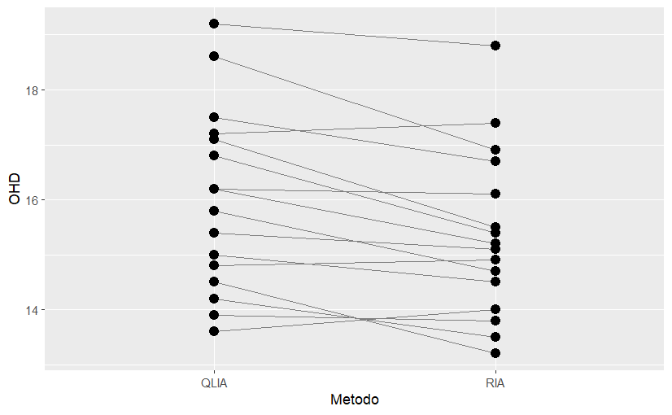

El gráfico de líneas (una línea por paciente) muestra que la mayoría de los puntos de QLIA están por encima de los de RIA.

### c) Parámetro e hipótesis

Definimos la diferencia por paciente  
d = RIA – QLIA.

Parámetro: μ_d = media poblacional de la diferencia.

Hipótesis bilateral  
H₀ : μ_d = 0 (ambos métodos dan, en promedio, el mismo valor)  
H₁ : μ_d ≠ 0

α = 0,05.

### d) Comprobación de supuestos

```
    Shapiro-Wilk normality test

data:  vitD$d
W = 0.96155, p-value = 0.69
```

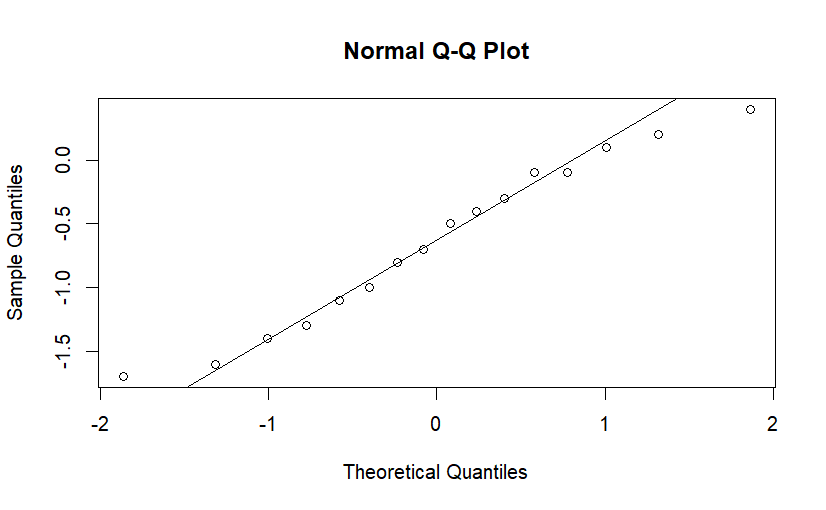

p = 0.69 → no se rechaza la normalidad; el gráfico QQ luce aceptable.  
⇒ Se cumplen los supuestos para el t-test pareado.

### e) Prueba de hipótesis y conclusión

```
    Paired t-test

data:  vitD$RIA and vitD$QLIA
t = -3.8999, df = 15, p-value = 0.001421
alternative hypothesis: true mean difference is not equal to 0
95 percent confidence interval:
 -0.9955838 -0.2919162
sample estimates:
mean difference
       -0.64375
```

Interpretación

• El valor-p = 0,0015 < 0,05 ⇒ se rechaza H₀.  
• El IC95 % para (RIA – QLIA) es (−0,996 ; −0,292) ng mL⁻¹, completamente negativo.

Conclusión (en palabras del problema)  
Con un 95 % de confianza existe evidencia de que los dos métodos NO entregan, en promedio, la misma concentración de 25-hidroxivitamina D. El método RIA produce valores aproximadamente 0,6 ng mL⁻¹ más bajos que el método automatizado de quimioluminiscencia (QLIA). Por lo tanto, al utilizar indistintamente ambos procedimientos debería contemplarse esta diferencia sistemática.

# Práctica 3

## Ejercicio 4 (Aylén)

Se realizó un experimento con el objetivo de evaluar el efecto que tienen la temperatura y el porcentaje de un compuesto sobre el rendimiento de una reacción química. Los tratamientos estudiados fueron las combinaciones de tres temperaturas y tres porcentajes del compuesto. Se realizaron un total de 18 reacciones utilizando un diseño balanceado, asignando al azar el orden en que se probaron los tratamientos. La respuesta medida fue la diferencia entre el rendimiento teórico de la reacción y el observado. Los valores observados se encuentran en el archivo “rendimiento.txt”. El objetivo final del problema es minimizar la diferencia entre el rendimiento teórico de la reacción y el observado. a) Realice un breve análisis descriptivo de los datos y describa brevemente lo observado en el mismo. b) Ajuste el modelo lineal apropiado para el diseño experimental y evalúe la existencia de efecto interacción entre temperatura y porcentaje del compuesto. ¿Puede ajustarse un modelo lineal “simplificado”? c) Verifique el cumplimiento de supuestos del modelo lineal elegido según la respuesta del punto anterior. d) Evalúe la existencia de efectos no lineales en los factores cuantitativos. e) Busque las condiciones que minimizan la diferencia entre el rendimiento teórico de la reacción y el observado y estime la respuesta media para dichas condiciones.

# Práctica 4

## Ejercicio 3 (Gonzalo)

Con referencia al artículo: Influencia del síndrome de Gilbert en los valores de bilirrubina sérica y presencia de litiasis vesicular en pacientes con hemólisis crónica congénita, a) ¿Cuál o cuáles variables se estudiaron en este trabajo? b) Defina los distintos tratamientos considerados. c) A partir de la observación de la Figura 2, fundamente la aplicación de la técnica estadística utilizada. d) ¿Cuál fue la conclusión a la que se llegó mediante el test de Kruskal-Wallis? e) ¿Qué comentarios puede realizar acerca de la utilización de la prueba de Mann-Whitney para comparar los valores de bilirrubina en tres pares de grupos? f) Comente los resultados finales.

# Práctica 5

## Ejercicio 3 (Gonzalo)

En disciplinas como la Ecología o la Biología de la Conservación, uno de los problemas comunes es la identificación de los factores que influyen en variables como la riqueza de una especie, medida en este caso como el número de individuos presentes en un área determinada. En un estudio sobre la población de un parásito, se registró el logaritmo del recuento de parásitos de dicha especie en 15 localizaciones con diversas condiciones ambientales. Como variables explicativas se consideraron la temperatura (x1, en °C) y el porcentaje de humedad (x2). Los datos obtenidos se encuentran en el archivo “parasito.txt”. a) Realice el ajuste del modelo de regresión lineal múltiple incluyendo las 2 variables explicativas como variables regresoras y escriba la función de regresión estimada. b) Ensaye la significación global de la regresión. c) Realice las pruebas de hipótesis que le permitan evaluar: i. Si el coeficiente de regresión β1 es igual a cero. ii. Si el coeficiente de regresión β2 es igual a cero. d) Evalúe la adecuación del modelo propuesto a través del valor de R2 y del análisis de residuos. e) Ajuste el modelo Y = 0 + 1x1+ ε. Utilice la información del modelo para probar la significación de la variable predictora Humedad con un test F. Ayuda: revisar test de significación para subconjuntos. ¿Coincide el resultado con el obtenido en el punto c? Justificar.